# COMP47670 Assignment 2: Text Classification

Name : Safiya Rehmat

Student Id : 18200494

## Introduction

This project is about text classification. Data is scraped from a website, yalp.com, prepared for modelling and classified based on the content. The labels for training are derived from the star-ratings given by the users.

Data collected from the website is stored in a sub-directory Data

Classifiers are built and trained to classify positive and negative reviews. Positive reviews are considered to be those for which the user gave a rating 4 or higher. Reviews with ratings less than 4 should be classified as negative reviews.

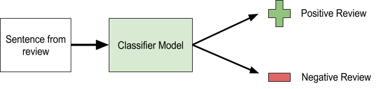

```python
import bs4 as bs
import urllib.request
import pandas as pd
import re
import nltk
from nltk.corpus import stopwords
from nltk.stem.porter import PorterStemmer
import seaborn as sns
import matplotlib.pyplot as plt
from sklearn.feature_extraction.text import CountVectorizer
from sklearn.model_selection import train_test_split
from sklearn.ensemble import RandomForestClassifier
from sklearn.naive_bayes import MultinomialNB
from sklearn.tree import DecisionTreeClassifier
from sklearn.neighbors import KNeighborsClassifier
from sklearn.svm import SVC
```

## Task 1 : Scrape reviews for 2 categories and store them as two separate datasets.

The two categories I have chosen for the assignment are:

```
    1. Automotives
    2. Health & Medical
```

#### These are two different datasets where users rate based on different factors. Our hypothesis is that the models trained on one dataset should not transfer well to dataset in the other category as the categories are very different.

The scraped data is stored as csv file along with the label in the sub-directory "Data". Category1.csv stores data about automobile reviews and Category2.csv stores reviews from the Health and Medical category.

```python
root_url = 'http://mlg.ucd.ie/modules/yalp/'
category1_url = root_url+'automotive_list.html'
category2_url = root_url+'health_medical_list.html'
```

```python
def scrape_data(category_url):
    # request the category url and convert to a beautiful soup object
    sauce = urllib.request.urlopen(category_url).read()
    soup = bs.BeautifulSoup(sauce,'lxml')
    text = []
    sentiment = []
    stars = []
    # get links for all items that have reviews on the category page and iterate over each link
    for url in soup.find_all('a'):
        review_url = root_url + url.get('href')
        r_sauce = urllib.request.urlopen(review_url).read()
        r_soup = bs.BeautifulSoup(r_sauce,'lxml')
        # iterate over each review
        for review in r_soup.find_all('div', class_='review'):
            star = review.find('p',class_='stars').img.get('alt')[0]
            stars.append(star)
            if (int(star)>=4):
                sentiment.append("positive")
            else:
                sentiment.append("negative")
            text.append(review.find('p',class_='text').text)
    #create a dataframe containing the review text, stars and sentiment
    df = pd.DataFrame({"text":text , "sentiment" : sentiment, "stars":stars})
    return df
```

```python
def write_data_to_file(df,file_name):
    df.to_csv(file_name,index=False)

df = scrape_data(category1_url)
print("Automobile Data \n ", df.head())
write_data_to_file(df,"Data/category1.csv")

df = scrape_data(category2_url)
print("\nHealth and Medical Data \n ", df.head())
write_data_to_file(df,"Data/category2.csv")
```

```
Automobile Data
                                                  text sentiment stars
0  I arrived at 3 PM and the dealership closed at...  positive     5
1  I dropped my car off on a Wednesday morning fo...  negative     1
2  My parents have been buying cars off of Donna ...  positive     5
3  I recently bought another car from Donna Dunni...  positive     5
4  I had to schedule an appointment due to the ai...  positive     5

Health and Medical Data
                                                  text sentiment stars
0  I have so many good things to say about this p...  positive     5
1  I found them to be highly skilled and an exper...  positive     5
2  Where do I even begin? This office has been so...  positive     5
3  I went in because I had toothache and needed a...  positive     5
4  Found a new dental office. This place is amazi...  positive     5
```

## Task 2 : Preprocess scraped data and Build and Evaluate model for both categories.

This task can be divided into 3 parts:

```
    1. Apply preprocessing steps to create a numeric representation of the data, suitable for classification.
    2. Build a classification model to distinguish between “positive” and “negative” reviews.
    3. Test the predictions of the classification model using an appropriate evaluation strategy.
```

### Part 1 : Apply Pre-Processing steps to create a numeric representation of the data.

Pre-processing the data involves the following steps:

```
1. Clean the review text . This involves removing all non-alphanumeric characters, converting them to lowercase, remove stopwords and stem each word.
2. Convert the text into a bag-of words using a Count-Vectorizer.
```

We don't have a tf-idf step as experiments including tf-idf approach showed that it does not improve performance significantly.

```python
def preprocess_data(df):
    # Initialize empty array to append clean text
    corpus = []

    # iterate over each review row to clean
    for i in range(0, df.shape[0]):

        # remove all non-alphanumeric characters
        review = re.sub('[^a-zA-Z0-9]', ' ', df['text'][i])

        # convert all cases to lower cases
        review = review.lower()

        # split to array(default delimiter is " ")
        review = review.split()

        # creating PorterStemmer object to take main stem of each word
        ps = PorterStemmer()
        # stem all words except the stop-words
        review = [ps.stem(word) for word in review
                    if not word in set(stopwords.words('english'))]

        review = ' '.join(review)

        # append each string to create array of clean text
        corpus.append(review)

    # Convert to bag of words usind count vectorizer
    cv = CountVectorizer(max_features = 1500)

    # X contains corpus (dependent variable)
    X = cv.fit_transform(corpus).toarray()

    # y contains labels of positive or negative reviews
    y = df.iloc[:, 1].values
    return X,y
```

### Splitting data for Testing and Training the model

We follow the approach of dividing the entire corpus into training and testing data. 25% of the data is kept for testing the model and the remaining 75% is used to train the model. Since the split is done randomly, we are not introducing sampling bias by keeping a seperate testing set.

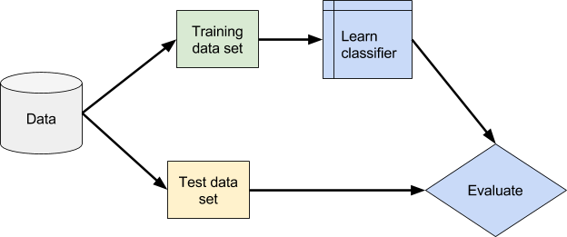

This approach to splitting the data into seperate testing and training sets was preferred over cross-validation as we had enough data and 75% of the data was still representative of the entire population and gave similar results. We did carry out preliminary tests with cross-validation approach to reach this conclusion. In the training phase of part 2, we print out the cross-validation scores on the the training data, just to verify the same.

```python
def get_test_train_split(X,y):
    # Splitting the dataset into the Training set and Test set
    X_train, X_test, y_train, y_test = train_test_split(X, y, test_size = 0.25)
    return X_train, X_test, y_train, y_test

from sklearn.metrics import confusion_matrix,accuracy_score,f1_score, classification_report
def get_performance(y_test,y_pred,verbose=False):
    print("\nPerformance on Test set:")
    print("Confusion Matrix")
    print(confusion_matrix(y_test, y_pred) )
    print("Accuracy Score:",round(accuracy_score(y_test,y_pred)*100,2))
    print("F1 Score:",round(f1_score(y_test,y_pred,average="weighted")*100,2))
    if(verbose):
        print("\nClassification Report:\n",classification_report(y_test, y_pred))
```

### Part 2 : Build a classification model to distinguish between “positive” and “negative” reviews.

As per the no-free-lunch theorem, no model performs well universally on all tasks. Thus, in this case we experiment with 5 classifiers for both category datasets and then choose the best performing ones for further analysis.

The 5 models chosen are:

```
1. Random Forest
2. Naive Bayes
3. Decision Trees
4. Support Vector Machines
5. K Nearest Neighbours
```

```python
from sklearn.model_selection import cross_val_score
def get_random_forest_model(X_train, X_test, y_train, y_test,verbose=False):

    model = RandomForestClassifier(n_estimators = 501,
                                criterion = 'entropy')
    model.fit(X_train, y_train)

    scores = cross_val_score(model,X_train,y_train,cv=5)
    print("\nAccuracy on Training set using cross-validation:",round(scores.mean()*100,2))

    # Predicting the Test set results
    y_pred = model.predict(X_test)
    get_performance(y_test,y_pred,verbose)

    return model, y_pred

def get_naive_bayes_model(X_train, X_test, y_train, y_test,verbose=False):

    model = MultinomialNB()
    model.fit(X_train, y_train)

    scores = cross_val_score(model,X_train,y_train,cv=5)
    print("\nAccuracy on Training set using cross-validation:",round(scores.mean()*100,2))

    # predicting the test results
    y_pred = model.predict(X_test)
    get_performance(y_test,y_pred,verbose)

    return model, y_pred

def get_decision_tree_model(X_train, X_test, y_train, y_test,verbose=False):

    dt = DecisionTreeClassifier()
    dt.fit(X_train,y_train)

    scores = cross_val_score(dt,X_train,y_train,cv=5)
    print("\nAccuracy on Training set using cross-validation:",round(scores.mean()*100,2))

    y_pred = dt.predict(X_test)
    get_performance(y_test,y_pred,verbose)

    return dt, y_pred

def get_knn_model(X_train, X_test, y_train, y_test,verbose=False):

    knn = KNeighborsClassifier(n_neighbors=10)
    knn.fit(X_train,y_train)

    scores = cross_val_score(knn,X_train,y_train,cv=5)
    print("\nAccuracy on Training set using cross-validation:",round(scores.mean()*100,2))

    y_pred = knn.predict(X_test)
    get_performance(y_test,y_pred,verbose)

    return knn, y_pred

def get_svm_model(X_train, X_test, y_train, y_test,verbose=False):

    svm = SVC(random_state=101, gamma = 'auto')
    svm.fit(X_train,y_train)

    scores = cross_val_score(svm,X_train,y_train,cv=5)
    print("\nAccuracy on Training set using cross-validation:",round(scores.mean()*100,2))

    y_pred = svm.predict(X_test)
    get_performance(y_test,y_pred,verbose)

    return svm, y_pred
```

### Category 1

```python
def get_data(file):
    df = pd.read_csv(file)
    x,y = preprocess_data(df)
    X_train, X_test, y_train, y_test  = get_test_train_split(x,y)
    return { "X_train": X_train, "X_test":X_test, "y_train":y_train, "y_test":y_test, "df":df}
```

```python
category1 = get_data("Data/category1.csv")
```

```python
X_train = category1["X_train"]
X_test = category1["X_test"]
y_train = category1["y_train"]
y_test = category1["y_test"]

print("\nRandom Forest Classifier")
get_random_forest_model(X_train, X_test, y_train, y_test)
print("\nDecision Tree Classifier")
get_decision_tree_model(X_train, X_test, y_train, y_test)
print("\nNaive Bayes Classifier")
get_naive_bayes_model(X_train, X_test, y_train, y_test)
print("\nkNN Classifier")
get_knn_model(X_train, X_test, y_train, y_test)
print("\nSVM Classifier")
get_svm_model(X_train, X_test, y_train, y_test)

print("")
```

```
Random Forest Classifier

Accuracy on Training set using cross-validation: 87.63

Performance on Test set:
Confusion Matrix
[[ 89  36]
 [  7 232]]
Accuracy Score: 88.19
F1 Score: 87.75

Decision Tree Classifier

Accuracy on Training set using cross-validation: 75.71

Performance on Test set:
Confusion Matrix
[[ 79  46]
 [ 36 203]]
Accuracy Score: 77.47
F1 Score: 77.23

Naive Bayes Classifier

Accuracy on Training set using cross-validation: 91.57

Performance on Test set:
Confusion Matrix
[[113  12]
 [ 12 227]]
Accuracy Score: 93.41
F1 Score: 93.41

kNN Classifier

Accuracy on Training set using cross-validation: 72.5

Performance on Test set:
Confusion Matrix
[[ 24 101]
 [  3 236]]
Accuracy Score: 71.43
F1 Score: 64.65

SVM Classifier

Accuracy on Training set using cross-validation: 71.13

Performance on Test set:
Confusion Matrix
[[ 26  99]
 [  3 236]]
Accuracy Score: 71.98
F1 Score: 65.59
```

### Category 2

```python
category2 = get_data("Data/category2.csv")
```

```python
X_train = category2["X_train"]
X_test = category2["X_test"]
y_train = category2["y_train"]
y_test = category2["y_test"]

print("\nRandom Forest Classifier")
get_random_forest_model(X_train, X_test, y_train, y_test)
print("\nDecision Tree Classifier")
get_decision_tree_model(X_train, X_test, y_train, y_test)
print("\nNaive Bayes Classifier")
get_naive_bayes_model(X_train, X_test, y_train, y_test)
print("\nkNN Classifier")
get_knn_model(X_train, X_test, y_train, y_test)
print("\nSVM Classifier")
get_svm_model(X_train, X_test, y_train, y_test)

print("")
```

```
Random Forest Classifier

Accuracy on Training set using cross-validation: 88.22

Performance on Test set:
Confusion Matrix
[[ 67  33]
 [  6 257]]
Accuracy Score: 89.26
F1 Score: 88.68

Decision Tree Classifier

Accuracy on Training set using cross-validation: 79.03

Performance on Test set:
Confusion Matrix
[[ 66  34]
 [ 40 223]]
Accuracy Score: 79.61
F1 Score: 79.79

Naive Bayes Classifier

Accuracy on Training set using cross-validation: 92.27

Performance on Test set:
Confusion Matrix
[[ 86  14]
 [ 15 248]]
Accuracy Score: 92.01
F1 Score: 92.02

kNN Classifier

Accuracy on Training set using cross-validation: 75.07

Performance on Test set:
Confusion Matrix
[[ 13  87]
 [  2 261]]
Accuracy Score: 75.48
F1 Score: 68.13

SVM Classifier

Accuracy on Training set using cross-validation: 75.8

Performance on Test set:
Confusion Matrix
[[ 16  84]
 [  3 260]]
Accuracy Score: 76.03
F1 Score: 69.48
```

### Part 3 : Test the predictions of the classification model using an appropriate evaluation strategy.

[figure not shown]

We can see from the table above that Naive Bayes performs best in both categories. Thus we will use Naive Bayes classifier for the rest of the experiments.

In this task, we will dig further into the performance of both category datasets with naive bayes classifier. We have used F1 score and accuracy to evaluate the classifier. In this section we generate the classifier report to evaluate how the model performs for each label("positive" and "negative") in both datasets.

### Category 1

```python
X_train = category1["X_train"]
X_test = category1["X_test"]
y_train = category1["y_train"]
y_test = category1["y_test"]

model1, y_pred = get_naive_bayes_model(X_train, X_test, y_train, y_test,verbose=True)
```

```
Accuracy on Training set using cross-validation: 91.57

Performance on Test set:
Confusion Matrix
[[113  12]
 [ 12 227]]
Accuracy Score: 93.41
F1 Score: 93.41

Classification Report:
               precision    recall  f1-score   support

    negative       0.90      0.90      0.90       125
    positive       0.95      0.95      0.95       239

   micro avg       0.93      0.93      0.93       364
   macro avg       0.93      0.93      0.93       364
weighted avg       0.93      0.93      0.93       364
```

### Category 2

```python
X_train = category2["X_train"]
X_test = category2["X_test"]
y_train = category2["y_train"]
y_test = category2["y_test"]

model2, y_pred = get_naive_bayes_model(X_train, X_test, y_train, y_test, verbose=True)
```

```
Accuracy on Training set using cross-validation: 92.27

Performance on Test set:
Confusion Matrix
[[ 86  14]
 [ 15 248]]
Accuracy Score: 92.01
F1 Score: 92.02

Classification Report:
               precision    recall  f1-score   support

    negative       0.85      0.86      0.86       100
    positive       0.95      0.94      0.94       263

   micro avg       0.92      0.92      0.92       363
   macro avg       0.90      0.90      0.90       363
weighted avg       0.92      0.92      0.92       363
```

From the results of both categories, we can see that the performance is better for positive class in comparison to the negative class. This may be because we have more examples of the positive class.

### Let us examine the number of reviews for both categories:

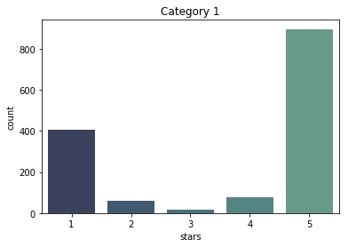

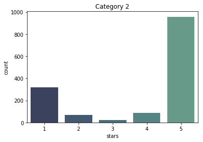

```python
def plot_data(df,title):

    fig, ax = plt.subplots()
    sns.countplot(x='stars', data=df, palette=sns.cubehelix_palette(9, start=.4, rot=-.70, reverse=True, light=0.85, dark=0.25))
    plt.title(title)


df = category1["df"]
plot_data(df,"Category 1")

df = category2["df"]
plot_data(df,"Category 2")
```

We can see most of the ratings are 5 stars. This is because people tend to leave reviews for things they really like or really dislike. Thus we get imbalanced data where one class is more dominant than the other.

There are many solutions proposed to solve the problem of imbalanced data. However, since we get reasonably decent results for both classes, we are not getting into those solutions. That can be the scope for a future extension of this project.

## Task 3 : Evaluate how well your two classification models transfer between category

#### Since our chosen categories, Automobiles and Health & Medical are very different from each other, Our hypothesis is that the models trained one dataset should not transfer well to dataset in the other category.

We test our hypothesis in this task by using the best performing model in part2 of the task. This task can be sub-divided into 2 parts:

### Part 1 : Train a classification model on “Category A”, and evaluate its performance on “Category B”

```python
X_train = category1["X_train"]
X_test = category2["X_test"]

y_train = category1["y_train"]
y_test = category2["y_test"]

model1, y_pred = get_naive_bayes_model(X_train, X_test, y_train, y_test, verbose=True)
```

```
Accuracy on Training set using cross-validation: 91.57

Performance on Test set:
Confusion Matrix
[[ 60  40]
 [140 123]]
Accuracy Score: 50.41
F1 Score: 52.86

Classification Report:
               precision    recall  f1-score   support

    negative       0.30      0.60      0.40       100
    positive       0.75      0.47      0.58       263

   micro avg       0.50      0.50      0.50       363
   macro avg       0.53      0.53      0.49       363
weighted avg       0.63      0.50      0.53       363
```

### Part 2 : Train a classification model on “Category B”, and evaluate its performance on “Category A”

```python
X_train = category2["X_train"]
X_test = category1["X_test"]

y_train = category2["y_train"]
y_test = category1["y_test"]

model2, y_pred = get_naive_bayes_model(X_train, X_test, y_train, y_test, verbose=True)
```

```
Accuracy on Training set using cross-validation: 92.27

Performance on Test set:
Confusion Matrix
[[ 67  58]
 [ 80 159]]
Accuracy Score: 62.09
F1 Score: 62.71

Classification Report:
               precision    recall  f1-score   support

    negative       0.46      0.54      0.49       125
    positive       0.73      0.67      0.70       239

   micro avg       0.62      0.62      0.62       364
   macro avg       0.59      0.60      0.60       364
weighted avg       0.64      0.62      0.63       364
```

This proves our hypothesis to be true that if the categories are different from each other, models trained on one category cannot be used to classify another category data.

## Conclusion

1. Naive Bayes classifier gives us the best text classification results for the given data, approx 92% accuracy.

2. Classifiers trained on one category data do not transfer well to another category of the two categories are different.